# Random data generation from Gaussian DAG models

R package: BCDAG vignettes vol.1

2022-05-20

Abstract

This is the first of a series of three vignettes introducing the R package BCDAG. In this vignette we focus on functions `rDAG()` and `rDAGWishart()` which implement random generation of DAG structures and DAG parameters under the assumption that the joint distribution of variables X_1, …, X_q is Gaussian and the corresponding model (Choleski) parameters follow a DAG-Wishart distribution. Finally, data generation from Gaussian DAG models is described.

**Random data generation from Gaussian DAG models**  
https://cran.r-project.org/web/packages/BCDAG/vignettes/bcdag_generatedata.html

# 1 Preparations

## 1.1 Packages

## 1.2 Environment

```r
# rgb(73, 81, 112, maxColorValue = 255)
col.tw <- "#dbd7d2"  # Timberwolf
col.os <- "#414a4c"  # Outer Space
col.rp <- "#7851a9"  # Royal Purple
col.pb <- "#1ca9c9"  # Pacific Blue
col.cb <- "#b0b7c6"  # Cadet Blue
col.el <- "#ceff1d"  # Electric Lime
col.cg <- "#00cc99"  # Caribbean Green
col.mt <- "#ff8243"  # Mango Tango
col.rm <- "#e3256b"  # Razzmatazz
col.sl <- "#fc2847"  # Scarlet
col.plos.yellow <- "#D6E13D"  # PLOS ONE Yellow
col.plos.pink <- "#CF00A3"  # PLOS ONE Pink
col.bmc.gray <- "#FFFDF6"  # BMC Gray
col.bmc.purple <- "#BF12F8"  # BMC Purple
col.bmc.navy <- "#1A2E4F"  # BMC Navy Blue
col.bmc.blue <- "#014A81"  # BMC Blue
col.bmc.sky <- "#0F99BE"  # BMC Sky Blue
col.bmc.green <- "#004940"  # BMC Deep Green
col.bmc.pink <- "#EF255F"  # BMC Pink
font.base <- "Candara"
# font.base <- "Times New Roman"
theme_set(theme_minimal(base_family = font.base))
options(dplyr.summarise.inform = TRUE)
# Twitter Logo and Acc
# Usage: add a code line below
# annotation_custom(grob = icon.grob, xmin = 1, xmax = 1, ymin = 1, ymax = 1)
icon.arr <- png::readPNG("fig/twitter.png")
icon.grob <- grid::rasterGrob(icon.arr,
                              width = unit(1.20 * 3, "cm"),
                              height = unit(0.99 * 3, "cm"),
                              interpolate = FALSE)
set.seed(2022)
```

# 2 Generating a binary adjacency matrix w/ `rDAG` function

`> rDAG(q, w)`  
rDAG() can be used to randomly generate a DAG structure $D = (V, E)$, where $V = \{1, ..., q\}$ and $E \subseteq V \times V$.

`Arguments`  
$q$: number of nodes  
$w$: the degree of sparsity

`Details`  
An adjacency matrix of the generated DAG, with element 1 at position $(u, v)$ indicating the presence of an edge $u \to v$.

```r
q <- 20
DAG <- rDAG(q = q, w = 0.5)
class(DAG)
```

```
## [1] "matrix" "array"
```

```r
DAG
```

```
##    1 2 3 4 5 6 7 8 9 10 11 12 13 14 15 16 17 18 19 20
## 1  0 0 0 0 0 0 0 0 0  0  0  0  0  0  0  0  0  0  0  0
## 2  1 0 0 0 0 0 0 0 0  0  0  0  0  0  0  0  0  0  0  0
## 3  1 1 0 0 0 0 0 0 0  0  0  0  0  0  0  0  0  0  0  0
## 4  0 1 1 0 0 0 0 0 0  0  0  0  0  0  0  0  0  0  0  0
## 5  1 1 1 1 0 0 0 0 0  0  0  0  0  0  0  0  0  0  0  0
## 6  0 0 1 1 1 0 0 0 0  0  0  0  0  0  0  0  0  0  0  0
## 7  1 0 1 0 1 0 0 0 0  0  0  0  0  0  0  0  0  0  0  0
## 8  0 0 0 0 1 0 1 0 0  0  0  0  0  0  0  0  0  0  0  0
## 9  0 1 1 0 1 0 1 1 0  0  0  0  0  0  0  0  0  0  0  0
## 10 0 1 1 0 1 1 0 0 0  0  0  0  0  0  0  0  0  0  0  0
## 11 1 1 1 1 0 1 1 1 1  0  0  0  0  0  0  0  0  0  0  0
## 12 0 0 0 1 1 0 1 1 1  1  1  0  0  0  0  0  0  0  0  0
## 13 0 1 1 1 1 0 1 0 0  1  1  1  0  0  0  0  0  0  0  0
## 14 0 0 1 1 0 1 0 1 0  1  1  1  1  0  0  0  0  0  0  0
## 15 1 1 0 0 0 0 1 1 1  1  1  1  0  0  0  0  0  0  0  0
## 16 1 0 1 1 0 0 0 1 0  0  0  0  1  1  0  0  0  0  0  0
## 17 0 0 0 0 0 0 1 0 1  1  0  1  1  0  1  1  0  0  0  0
## 18 1 0 0 0 1 0 1 0 0  1  1  1  0  1  0  0  1  0  0  0
## 19 1 0 1 0 1 1 1 0 1  0  1  0  1  0  0  1  1  1  0  0
## 20 1 1 0 1 0 1 0 0 1  1  1  1  0  1  0  0  0  1  1  0
```

# 3 Visualization of generated DAG via `tidygraph` and `ggraph`

Reference: https://ggplot2-book.org/networks.html#networks

## 3.1 Convert adjacency matrix to tidygraph object

A tbl_graph object has Node and Edge Data.

```r
dag.tg <- tidygraph::as_tbl_graph(DAG, directed = TRUE)
class(dag.tg)
```

```
## [1] "tbl_graph" "igraph"
```

```r
dag.tg
```

```
## # A tbl_graph: 20 nodes and 108 edges
## #
## # A directed acyclic simple graph with 1 component
## #
## # Node Data: 20 x 1 (active)
##   name
##   <chr>
## 1 1
## 2 2
## 3 3
## 4 4
## 5 5
## 6 6
## # ... with 14 more rows
## #
## # Edge Data: 108 x 3
##    from    to weight
##   <int> <int>  <dbl>
## 1     2     1      1
## 2     3     1      1
## 3     3     2      1
## # ... with 105 more rows
```

## 3.2 Draw Networks

`ggraph` makes ggplot object from tbl_graph object.  
Layout **circlepack** is cool!

```r
set_graph_style(plot_margin = margin(1, 1, 1, 1))
class(ggraph(dag.tg))
```

```
## [1] "ggraph" "gg"     "ggplot"
```

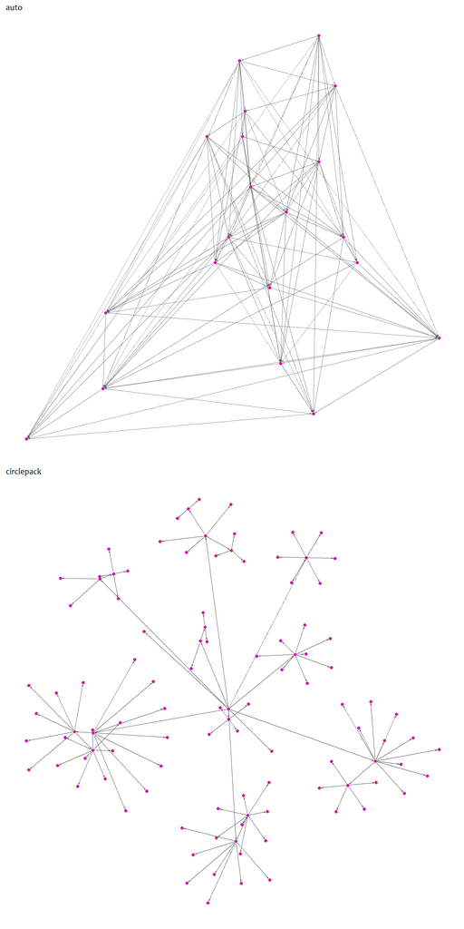

```r
p1 <- ggraph(dag.tg, layout = "auto") +
    geom_edge_link(
        arrow = grid::arrow(angle = 15, length = unit(3, "pt")),
        start_cap = circle(3, "pt"),
        end_cap = circle(3, "pt"),
        color = col.os,
        edge_width = 0.5, edge_alpha = 0.5
    ) +
    geom_node_point(color = col.plos.pink, size = 2, alpha = 0.9) +
    theme_minimal(base_family = font.base) +
    labs(title = "auto", x = NULL, y = NULL) +
    theme(
        axis.text = element_blank(),
        panel.grid.major = element_blank(),
        panel.grid.minor = element_blank(),
    )
p2 <- ggraph(dag.tg, layout = "circlepack") +
    geom_edge_link(
        arrow = arrow(angle = 15, length = unit(3, "pt")),
        start_cap = circle(3, "pt"),
        end_cap = circle(3, "pt"),
        color = col.os,
        edge_width = 0.5, edge_alpha = 0.75
    ) +
    geom_node_point(color = col.plos.pink, size = 2, alpha = 0.9) +
    theme_minimal(base_family = font.base) +
    labs(title = "circlepack", x = NULL, y = NULL) +
    theme(
        axis.text = element_blank(),
        panel.grid.major = element_blank(),
        panel.grid.minor = element_blank(),
    )
p1 / p2
```

```r
ggsave(filename = "fig/BCDAG-01-1.jpg", dpi = 200, width = 5, height = 10)
```

# 4 Generating Gaussian DAG parameters w/ `rDAGWishart` function

Consider **a Gaussian DAG model** of the form  
$f(X_1, ..., X_q | L,D) \sim N_q(0, (L D^{-1} L^T)^{-1})$,  
where $(L, D)$ are model parameters providing the decomposition of the **precision (inverse-covariance) matrix** $\Omega = L D^{-1} L^T$; specifically, $L$ is a $(q, q)$ matrix of coefficients such that for each $(u, v)$-element $L_{uv}$ with $u \neq v$, we have $L_{uv} \neq 0$ if and only if $(u, v) \subset E$, while $L_{uu} = 1$ for each $u = 1, ..., q$; also, $D$ is a $(q, q)$ diagonal matrix with $(u, u)$-element $D_{uu}$. The latter decomposition follows from the equivalent Structural Equation Model (SEM) representation of a Gaussian DAG model:

$L^{⊤} x = \epsilon , \epsilon \sim N_q(0, D)$,

where $x = (X_1, ..., X_q)^⊤$; see also Castelletti & Mascaro (2021). This is just a Cholesky decomposition.

Function `rDAGWishart` implements random sampling from $(L, D)|D \sim \mathrm{DAGWishart} (a^D_c, U)$, where $U$ is the `rate parameter` (a $(q, q)$ s.p.d. matrix) and $a^D_c$ (a $(q, 1)$ vector) is the `shape parameter` of the DAG-Wishart distribution. This class of distributions was introduced by Ben David et al. (2015) as a `conjugate prior` for Gaussian DAG model-parameters. In its compatible version (Peluso & Consonni, 2020), elements of the vector parameter $a^D_c$ are uniquely determined from a single common shape parameter $a \gt q - 1$.

```r
a <- q
U <- diag(1, q)
outDL <- rDAGWishart(n = 2, DAG, a, U)
class(outDL)
```

```
## [1] "list"
```

The output of rDAGWishart() consists of two elements, $L$ and $D$ referred above equation for Gaussian DAG.

```r
L <- outDL$L
class(L)
```

```
## [1] "array"
```

```r
dim(L)
```

```
## [1] 20 20  2
```

```r
class(L[, , 1])
```

```
## [1] "matrix" "array"
```

```r
diag(L[, , 1])
```

```
##  [1] 1 1 1 1 1 1 1 1 1 1 1 1 1 1 1 1 1 1 1 1
```

```r
D <- outDL$D
class(D)
```

```
## [1] "array"
```

```r
dim(D)
```

```
## [1] 20 20  2
```

```r
class(D[, , 1])
```

```
## [1] "matrix" "array"
```

```r
sum(D[, , 1] > 0)
```

```
## [1] 20
```

# 5 Generating Data from a Gaussian DAG

`> solve(a, h)`  
If missing, b is taken to be an identity matrix and solve will return the inverse of a!

```r
# Precision matrix: L D^-1 L^T
Omega <- L[, , 1] %*% solve(D[, , 1]) %*% t(L[, , 1])
# Covariance matrix
Sigma <- solve(Omega)
```

```r
# MultiVariate Normal Distribution
x.mvn <- mvtnorm::rmvnorm(n = 10, sigma = Sigma)
dim(x.mvn)
```

```
## [1] 10 20
```